# Lineage Area Review

## Overview

This notebook reviews the saved area analyses across all lineages and highlights the most promising long-term distribution changes.

The intended use is:

1. Rank lineages by how strongly their adjusted area distributions change across passages.
2. Pick one promising lineage and transition.
3. Inspect the raw image panel around that transition to check whether the statistical signal looks real.

## Packages

```r
required_packages <- c(
  "dplyr",
  "ggplot2",
  "purrr",
  "readr",
  "tibble",
  "tidyr",
  "stringr",
  "scales"
)

missing_packages <- required_packages[!vapply(required_packages, requireNamespace, logical(1), quietly = TRUE)]
if (length(missing_packages) > 0) {
  stop(
    sprintf(
      "Install required packages before rendering: %s",
      paste(missing_packages, collapse = ", ")
    ),
    call. = FALSE
  )
}

library(dplyr)
library(ggplot2)
library(purrr)
library(readr)
library(tibble)
library(tidyr)
library(stringr)
library(scales)
```

## Helpers

```r
resolve_project_root <- function() {
  candidates <- c(
    normalizePath(".", winslash = "/", mustWork = FALSE),
    normalizePath("..", winslash = "/", mustWork = FALSE),
    normalizePath("../..", winslash = "/", mustWork = FALSE)
  )

  for (candidate in unique(candidates)) {
    if (file.exists(file.path(candidate, "README.md")) &&
        dir.exists(file.path(candidate, "workflows"))) {
      return(candidate)
    }
  }

  stop("Could not locate project root from current working directory.", call. = FALSE)
}

project_root <- resolve_project_root()

project_path <- function(path) {
  is_absolute <- grepl("^[A-Za-z]:[/\\\\]|^/", path)
  out <- path
  out[!is_absolute] <- file.path(project_root, path[!is_absolute])
  out
}

analysis_dir_from_id <- function(lineage_id) {
  file.path(project_path(params$all_results_dir), paste0("lineage_", lineage_id))
}

parse_datetime_safe <- function(x) {
  if (inherits(x, "POSIXct")) return(x)
  x <- as.character(x)
  out <- as.POSIXct(rep(NA_character_, length(x)), tz = "UTC")
  formats <- c(
    "%Y-%m-%d %H:%M:%S",
    "%Y-%m-%dT%H:%M:%SZ",
    "%Y-%m-%d %H:%M:%OS",
    "%m/%d/%Y %H:%M",
    "%m/%d/%Y %H:%M:%S"
  )
  for (fmt in formats) {
    missing <- is.na(out) & !is.na(x) & nzchar(x)
    if (!any(missing)) next
    out[missing] <- as.POSIXct(x[missing], format = fmt, tz = "UTC")
  }
  out
}

safe_quantile <- function(x, prob) {
  if (!length(x) || all(is.na(x))) return(NA_real_)
  as.numeric(stats::quantile(x, probs = prob, na.rm = TRUE, names = FALSE))
}

rescale_01 <- function(x) {
  rng <- range(x, na.rm = TRUE)
  if (!all(is.finite(rng)) || diff(rng) <= 0) return(rep(0, length(x)))
  (x - rng[[1]]) / diff(rng)
}

normalize_for_display <- function(img) {
  img <- as.array(img)
  if (length(dim(img)) == 3) {
    img <- apply(img[, , seq_len(min(3, dim(img)[3])), drop = FALSE], c(1, 2), mean)
  }
  q <- stats::quantile(img, probs = c(0.01, 0.99), na.rm = TRUE, names = FALSE)
  img <- pmin(pmax(img, q[[1]]), q[[2]])
  img <- img - min(img, na.rm = TRUE)
  mx <- max(img, na.rm = TRUE)
  if (is.finite(mx) && mx > 0) {
    img <- img / mx
  }
  img
}

plot_grayscale_matrix <- function(img, main = "") {
  raster_img <- as.raster(img[nrow(img):1, ], max = 1)
  plot.new()
  usr <- par("usr")
  rasterImage(raster_img, usr[1], usr[3], usr[2], usr[4], interpolate = FALSE)
  title(main = main, cex.main = 0.8)
}

read_analysis_bundle <- function(path) {
  obj <- readRDS(path)
  list(
    lineage_id = as.character(obj$lineage_id),
    cells = tibble::as_tibble(obj$cells),
    image_summary = tibble::as_tibble(obj$image_summary),
    passage_summary = tibble::as_tibble(obj$passage_summary)
  )
}

smooth_series <- function(x) {
  x <- as.numeric(x)
  n <- length(x)
  if (n <= 2) return(x)
  k <- min(5, if (n %% 2 == 1) n else n - 1)
  if (k < 3) k <- 3
  k <- min(k, if (n %% 2 == 1) n else n - 1)
  if (k < 3) return(x)
  stats::runmed(x, k = k, endrule = "median")
}

lineage_trend_summary <- function(df) {
  df <- df %>% arrange(passage_position)
  n_passages <- nrow(df)
  if (n_passages < 3) {
    return(tibble(
      n_passages = n_passages,
      start_passage_id = df$passage_id[[1]],
      end_passage_id = df$passage_id[[n_passages]],
      smooth_delta_median_z = NA_real_,
      smooth_delta_iqr_z = NA_real_,
      smooth_delta_q99_z = NA_real_,
      smooth_delta_frac_z_gt_3 = NA_real_,
      max_adjacent_jump_q99_z = NA_real_,
      max_adjacent_jump_frac_z_gt_3 = NA_real_,
      monotonicity_median = NA_real_,
      monotonicity_q99 = NA_real_,
      monotonicity_frac_z_gt_3 = NA_real_,
      long_term_score = NA_real_
    ))
  }

  med_s <- smooth_series(df$median_z)
  iqr_s <- smooth_series(df$iqr_z)
  q99_s <- smooth_series(df$q99_z)
  frac_s <- smooth_series(df$frac_z_gt_3)

  calc_monotonicity <- function(x) {
    net <- abs(x[[length(x)]] - x[[1]])
    total <- sum(abs(diff(x)))
    if (!is.finite(total) || total <= 0) return(0)
    net / total
  }

  delta_med <- med_s[[length(med_s)]] - med_s[[1]]
  delta_iqr <- iqr_s[[length(iqr_s)]] - iqr_s[[1]]
  delta_q99 <- q99_s[[length(q99_s)]] - q99_s[[1]]
  delta_frac <- frac_s[[length(frac_s)]] - frac_s[[1]]

  monotonicity_median <- calc_monotonicity(med_s)
  monotonicity_q99 <- calc_monotonicity(q99_s)
  monotonicity_frac <- calc_monotonicity(frac_s)

  long_term_score_raw <-
    abs(delta_med) +
    0.5 * abs(delta_iqr) +
    1.5 * abs(delta_q99) +
    8 * abs(delta_frac)

  consistency_weight <- mean(c(monotonicity_median, monotonicity_q99, monotonicity_frac), na.rm = TRUE)
  long_term_score <- long_term_score_raw * consistency_weight * log1p(n_passages)

  tibble(
    n_passages = n_passages,
    start_passage_id = df$passage_id[[1]],
    end_passage_id = df$passage_id[[n_passages]],
    smooth_delta_median_z = delta_med,
    smooth_delta_iqr_z = delta_iqr,
    smooth_delta_q99_z = delta_q99,
    smooth_delta_frac_z_gt_3 = delta_frac,
    max_adjacent_jump_q99_z = max(abs(diff(df$q99_z)), na.rm = TRUE),
    max_adjacent_jump_frac_z_gt_3 = max(abs(diff(df$frac_z_gt_3)), na.rm = TRUE),
    monotonicity_median = monotonicity_median,
    monotonicity_q99 = monotonicity_q99,
    monotonicity_frac_z_gt_3 = monotonicity_frac,
    long_term_score = long_term_score
  )
}
```

## Discover Analysis Outputs

```r
all_results_dir <- project_path(params$all_results_dir)
analysis_paths <- list.files(
  all_results_dir,
  pattern = "lineage_area_analysis\\.rds$",
  recursive = TRUE,
  full.names = TRUE
)

if (!length(analysis_paths)) {
  stop(sprintf("No lineage analysis outputs found under %s", all_results_dir), call. = FALSE)
}

analysis_index <- tibble(
  analysis_rds = analysis_paths,
  analysis_dir = dirname(analysis_paths),
  lineage_id = sub("^lineage_", "", basename(dirname(analysis_paths)))
)

knitr::kable(
  tibble(
    n_lineages_found = nrow(analysis_index),
    results_dir = all_results_dir
  )
)
```

| n_lineages_found | results_dir |
| --- | --- |
| 82 | /share/lab_crd/lab_crd/CLONEID/anaMorph/data/lineage_area |

## Load Summary Metrics Across All Lineages

```r
summary_bundle <- purrr::map(analysis_index$analysis_rds, read_analysis_bundle)

all_passage_tbl <- purrr::map2_dfr(summary_bundle, analysis_index$analysis_dir, function(bundle, analysis_dir) {
  bundle$passage_summary %>%
    mutate(
      lineage_id = bundle$lineage_id,
      analysis_dir = analysis_dir,
      passage_position = as.integer(passage_position),
      first_image_time = parse_datetime_safe(first_image_time)
    )
})

all_image_tbl <- purrr::map2_dfr(summary_bundle, analysis_index$analysis_dir, function(bundle, analysis_dir) {
  bundle$image_summary %>%
    mutate(
      lineage_id = bundle$lineage_id,
      analysis_dir = analysis_dir,
      passage_position = as.integer(passage_position)
    )
})
```

## Rank The Most Promising Long-Term Lineages

```r
lineage_rank_tbl <- all_passage_tbl %>%
  arrange(lineage_id, passage_position) %>%
  group_by(lineage_id) %>%
  group_modify(~ lineage_trend_summary(.x)) %>%
  ungroup() %>%
  filter(is.finite(long_term_score)) %>%
  arrange(desc(long_term_score))

top_lineage_tbl <- lineage_rank_tbl %>%
  select(
    lineage_id,
    n_passages,
    start_passage_id,
    end_passage_id,
    long_term_score,
    smooth_delta_median_z,
    smooth_delta_iqr_z,
    smooth_delta_q99_z,
    smooth_delta_frac_z_gt_3,
    monotonicity_median,
    monotonicity_q99,
    monotonicity_frac_z_gt_3
  ) %>%
  slice_head(n = 15)

knitr::kable(top_lineage_tbl, digits = 3)
```

| lineage_id | n_passages | start_passage_id | end_passage_id | long_term_score | smooth_delta_median_z | smooth_delta_iqr_z | smooth_delta_q99_z | smooth_delta_frac_z_gt_3 | monotonicity_median | monotonicity_q99 | monotonicity_frac_z_gt_3 |
| --- | --- | --- | --- | --- | --- | --- | --- | --- | --- | --- | --- |
| 89 | 34 | SNU-668_A1_seed | SNU-668_C_A27_seed | 20.218 | -1.600 | -1.914 | -3.699 | -0.127 | 0.343 | 0.830 | 0.697 |
| 166 | 37 | SNU-668_A1_seed | SNU-668_RevC_A30_seed | 16.948 | -2.887 | -1.989 | -3.683 | -0.087 | 0.363 | 0.677 | 0.343 |
| 17 | 7 | HGC-27_P1_A6_seed | HGC-27_P1_A12_seed | 12.729 | 0.877 | 0.807 | 2.361 | 0.162 | 1.000 | 1.000 | 1.000 |
| 87 | 28 | SNU-668_A1_seed | SNU-668_C_A21b_seed | 12.087 | -0.085 | -2.667 | -3.285 | -0.114 | 0.026 | 0.767 | 0.691 |
| 277 | 12 | SUM-159_NLS_4N_C_A1_seed | SUM-159_NLS_4N_C_A12_seed | 10.839 | -1.313 | -0.193 | -1.586 | -0.055 | 1.000 | 1.000 | 1.000 |
| 170 | 10 | SNU-668_A1_seed | SNU-668_RevG_A2-K_seed | 10.377 | 0.752 | -2.250 | -1.922 | -0.067 | 0.453 | 1.000 | 1.000 |
| 92 | 18 | SNU-668_A1_seed | SNU-668_G1_A11b_seed | 7.663 | 1.692 | -2.637 | 1.899 | 0.065 | 0.675 | 0.224 | 0.325 |
| 21 | 7 | HGC-27_P2_A6_seed | HGC-27_P2_A12_seed | 6.966 | 2.251 | 0.018 | 0.660 | 0.043 | 1.000 | 0.797 | 1.000 |
| 169 | 18 | SNU-668_A1_seed | SNU-668_RevG_A11_seed | 6.849 | 0.192 | 0.267 | 1.743 | 0.046 | 0.195 | 0.963 | 0.953 |
| 260 | 12 | SUM-159_NLS_2N_C_A1_seed | SUM-159_NLS_2N_C_A12_seed | 6.830 | -1.288 | -0.048 | -0.813 | -0.056 | 1.000 | 0.753 | 0.928 |
| 90 | 13 | SNU-668_A1_seed | SNU-668_C_A4KT_seed | 6.790 | 0.227 | -2.259 | -1.552 | -0.083 | 0.153 | 0.662 | 0.960 |
| 123 | 11 | SNU-668_A1_seed | SNU-668_P1_A4_seed | 6.594 | 1.622 | -0.977 | -0.981 | -0.017 | 1.000 | 0.774 | 0.368 |
| 94 | 14 | SNU-668_A1_seed | SNU-668_G1_A6-K_seed | 5.952 | 0.026 | -2.595 | -3.302 | -0.096 | 0.008 | 0.558 | 0.370 |
| 16 | 6 | HGC-27_P1_A6_seed | HGC-27_P0_A2_seed | 5.618 | 0.750 | 0.493 | 1.015 | 0.046 | 1.000 | 1.000 | 1.000 |
| 51 | 6 | MDA-MB-231_O1_A1_seed | MDA-MB-231_O1_A6_seed | 5.405 | -0.667 | -0.170 | -1.177 | -0.032 | 1.000 | 1.000 | 1.000 |

Interpretation:

- `smooth_delta_*` values measure start-to-end change after median smoothing across passages.
- `monotonicity_*` downweights lineages that only look interesting because of one sharp jump and reversal.
- `long_term_score` is meant to prioritize persistent drift, especially in the upper tail, rather than single noisy transitions.

## Cross-Lineage Summary Plots

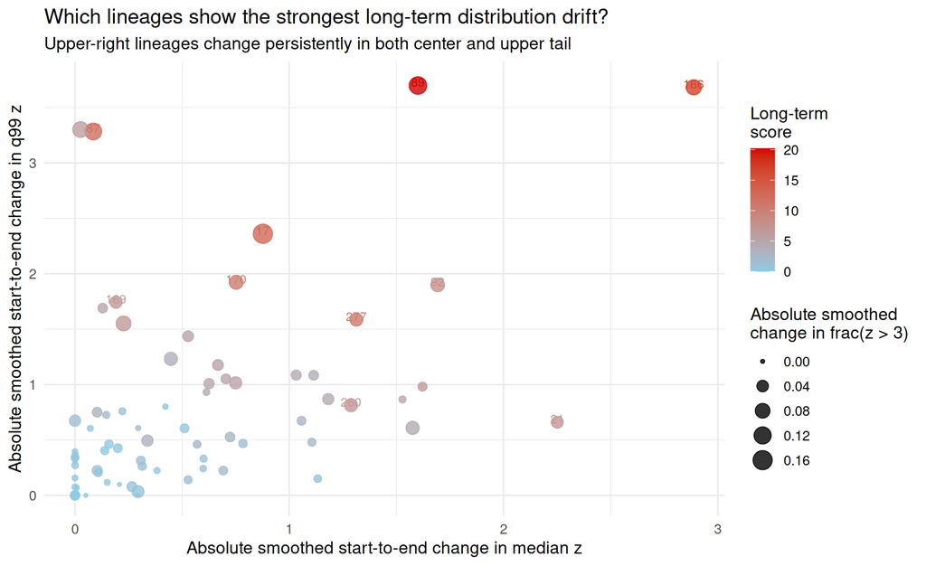

```r
ggplot(
  lineage_rank_tbl,
  aes(
    x = abs(smooth_delta_median_z),
    y = abs(smooth_delta_q99_z),
    size = abs(smooth_delta_frac_z_gt_3),
    color = long_term_score
  )
) +
  geom_point(alpha = 0.8) +
  geom_text(
    data = slice_head(lineage_rank_tbl, n = 10),
    aes(label = lineage_id),
    nudge_y = 0.03,
    size = 3,
    show.legend = FALSE
  ) +
  scale_color_gradient(low = "#8ecae6", high = "#d00000") +
  labs(
    title = "Which lineages show the strongest long-term distribution drift?",
    subtitle = "Upper-right lineages change persistently in both center and upper tail",
    x = "Absolute smoothed start-to-end change in median z",
    y = "Absolute smoothed start-to-end change in q99 z",
    size = "Absolute smoothed\nchange in frac(z > 3)",
    color = "Long-term\nscore"
  ) +
  theme_minimal(base_size = 12)
```

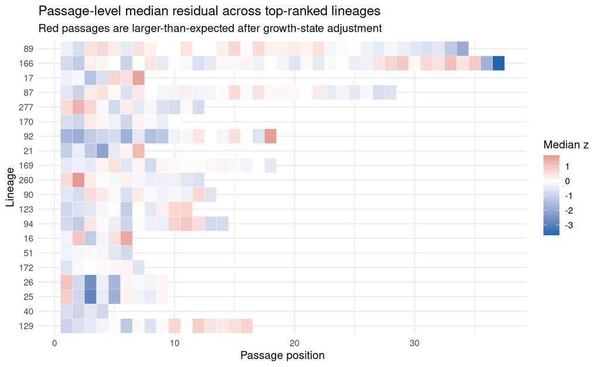

```r
top_lineages <- lineage_rank_tbl %>%
  slice_head(n = 20) %>%
  pull(lineage_id)

heatmap_tbl <- all_passage_tbl %>%
  filter(lineage_id %in% top_lineages) %>%
  mutate(lineage_id = factor(lineage_id, levels = rev(top_lineages)))

ggplot(heatmap_tbl, aes(x = passage_position, y = lineage_id, fill = median_z)) +
  geom_tile(color = "white") +
  scale_fill_gradient2(low = "#2166ac", mid = "white", high = "#b2182b", midpoint = 0) +
  labs(
    title = "Passage-level median residual across top-ranked lineages",
    subtitle = "Red passages are larger-than-expected after growth-state adjustment",
    x = "Passage position",
    y = "Lineage",
    fill = "Median z"
  ) +
  theme_minimal(base_size = 12)
```

## Choose A Focus Lineage

```r
best_lineage_tbl <- lineage_rank_tbl %>% slice(1)

focus_lineage_id <- params$lineage_id
if (is.null(focus_lineage_id) || !nzchar(focus_lineage_id)) {
  focus_lineage_id <- best_lineage_tbl$lineage_id[[1]]
}

focus_analysis_dir <- params$analysis_dir
if (is.null(focus_analysis_dir) || !nzchar(focus_analysis_dir)) {
  focus_analysis_dir <- analysis_dir_from_id(focus_lineage_id)
}
focus_analysis_rds <- file.path(project_path(focus_analysis_dir), "lineage_area_analysis.rds")

focus_obj <- read_analysis_bundle(focus_analysis_rds)

focus_cell_tbl <- focus_obj$cells %>%
  mutate(
    lineage_id = as.character(lineage_id),
    passage_position = as.integer(passage_position),
    p_small = as.numeric(p_small),
    p_real = as.numeric(p_real),
    z = as.numeric(z),
    log_area = as.numeric(log_area),
    time_since_passage_start_hours = as.numeric(time_since_passage_start_hours),
    log_confluence = as.numeric(log_confluence)
  )

focus_image_tbl <- focus_obj$image_summary %>%
  mutate(passage_position = as.integer(passage_position))

focus_passage_tbl <- focus_obj$passage_summary %>%
  mutate(
    passage_position = as.integer(passage_position),
    first_image_time = parse_datetime_safe(first_image_time)
  ) %>%
  arrange(passage_position)

focus_lineage_rank_tbl <- lineage_rank_tbl %>%
  filter(lineage_id == focus_lineage_id) %>%
  slice_head(n = 1)

if (!inherits(focus_lineage_rank_tbl, "data.frame") || nrow(focus_lineage_rank_tbl) == 0) {
  stop(sprintf("No ranked lineage summary found for lineage %s", focus_lineage_id), call. = FALSE)
}

focus_summary_tbl <- tibble(
  focus_lineage_id = focus_lineage_id,
  start_passage_id = focus_lineage_rank_tbl$start_passage_id[[1]],
  end_passage_id = focus_lineage_rank_tbl$end_passage_id[[1]],
  focus_trend = paste0(
    focus_lineage_rank_tbl$start_passage_id[[1]],
    " -> ",
    focus_lineage_rank_tbl$end_passage_id[[1]]
  ),
  long_term_score = focus_lineage_rank_tbl$long_term_score[[1]]
)

knitr::kable(focus_summary_tbl, digits = 3)
```

| focus_lineage_id | start_passage_id | end_passage_id | focus_trend | long_term_score |
| --- | --- | --- | --- | --- |
| 89 | SNU-668_A1_seed | SNU-668_C_A27_seed | SNU-668_A1_seed -> SNU-668_C_A27_seed | 20.218 |

## Focus Lineage: Distributional Review

```r
focus_display_tbl <- focus_passage_tbl %>%
  transmute(
    passage_position,
    passage_id,
    n_objects,
    effective_n = round(effective_n, 1),
    nuisance_fraction = round(nuisance_fraction, 3),
    median_z = round(median_z, 3),
    iqr_z = round(iqr_z, 3),
    q95_z = round(q95_z, 3),
    q99_z = round(q99_z, 3),
    frac_z_gt_2 = round(frac_z_gt_2, 3),
    frac_z_gt_3 = round(frac_z_gt_3, 3)
  )

knitr::kable(focus_display_tbl)
```

| passage_position | passage_id | n_objects | effective_n | nuisance_fraction | median_z | iqr_z | q95_z | q99_z | frac_z_gt_2 | frac_z_gt_3 |
| --- | --- | --- | --- | --- | --- | --- | --- | --- | --- | --- |
| 1 | SNU-668_A1_seed | 4178 | 2389.1 | 0.428 | -0.312 | 5.287 | 4.498 | 6.370 | 0.230 | 0.132 |
| 2 | SNU-668_A2_seed | 4523 | 2533.6 | 0.440 | -0.754 | 4.730 | 5.568 | 8.071 | 0.243 | 0.171 |
| 3 | SNU-668_A3_seed | 9200 | 5919.3 | 0.357 | 0.501 | 3.517 | 5.559 | 8.439 | 0.277 | 0.171 |
| 4 | SNU-668_A5_seed | 12089 | 8041.2 | 0.335 | 0.655 | 3.650 | 4.795 | 8.127 | 0.286 | 0.159 |
| 5 | SNU-668_A7_seed | 9559 | 6246.6 | 0.347 | 0.347 | 2.779 | 3.930 | 6.925 | 0.202 | 0.100 |
| 6 | SNU-668_dp_A8_seed | 8062 | 5898.2 | 0.268 | -0.476 | 2.555 | 2.917 | 5.192 | 0.099 | 0.046 |
| 7 | SNU-668_dp_A9_seed | 12515 | 9146.2 | 0.269 | 0.494 | 2.695 | 3.629 | 5.786 | 0.215 | 0.091 |
| 8 | SNU-668_C_A1_seed | 15344 | 11203.7 | 0.270 | 0.256 | 2.824 | 3.683 | 5.732 | 0.193 | 0.089 |
| 9 | SNU-668_C_A2_seed | 10928 | 7905.8 | 0.277 | 0.009 | 2.916 | 3.442 | 5.496 | 0.170 | 0.078 |
| 10 | SNU-668_C_A3_seed | 6041 | 4391.7 | 0.273 | -0.025 | 2.714 | 3.377 | 5.628 | 0.152 | 0.066 |
| 11 | SNU-668_C_A4_seed | 12336 | 9049.0 | 0.266 | 0.470 | 2.697 | 3.851 | 6.114 | 0.212 | 0.102 |
| 12 | SNU-668_C_A5_seed | 18410 | 13249.9 | 0.280 | -0.005 | 2.659 | 3.296 | 5.552 | 0.147 | 0.063 |
| 13 | SNU-668_C_A6_seed | 14280 | 10359.6 | 0.275 | 0.019 | 2.687 | 3.548 | 5.894 | 0.154 | 0.074 |
| 14 | SNU-668_C_A7_seed | 16836 | 12418.9 | 0.262 | 0.271 | 2.638 | 3.603 | 5.703 | 0.183 | 0.084 |
| 15 | SNU-668_C_A8_seed | 9135 | 6705.3 | 0.266 | 0.707 | 2.620 | 3.896 | 6.200 | 0.244 | 0.106 |
| 16 | SNU-668_C_A9_seed | 8227 | 6031.9 | 0.267 | 0.063 | 2.642 | 3.571 | 5.904 | 0.163 | 0.077 |
| 17 | SNU-668_C_A10_seed | 8875 | 6475.6 | 0.270 | 0.623 | 2.692 | 3.942 | 6.318 | 0.235 | 0.112 |
| 18 | SNU-668_C_A11_seed | 6882 | 5046.0 | 0.267 | 0.237 | 2.719 | 3.459 | 5.813 | 0.177 | 0.076 |
| 19 | SNU-668_C_A12_seed | 5614 | 4140.4 | 0.262 | 0.279 | 2.545 | 3.425 | 5.864 | 0.166 | 0.075 |
| 20 | SNU-668_C_A13_seed | 15778 | 11525.2 | 0.270 | 0.323 | 2.753 | 3.846 | 6.345 | 0.199 | 0.093 |
| 21 | SNU-668_C_A14_seed | 9983 | 7314.1 | 0.267 | 0.211 | 2.714 | 3.496 | 5.274 | 0.182 | 0.077 |
| 22 | SNU-668_C_A15_seed | 6936 | 5124.6 | 0.261 | 0.510 | 2.582 | 3.700 | 5.905 | 0.213 | 0.093 |
| 23 | SNU-668_C_A16_seed | 14528 | 10525.4 | 0.276 | -0.170 | 2.786 | 3.223 | 5.441 | 0.136 | 0.060 |
| 24 | SNU-668_C_A17_seed | 7168 | 5294.4 | 0.261 | -0.061 | 2.779 | 3.171 | 5.302 | 0.144 | 0.059 |
| 25 | SNU-668_C_A18_seed | 14616 | 10635.8 | 0.272 | 0.014 | 2.783 | 3.201 | 5.297 | 0.150 | 0.060 |
| 26 | SNU-668_C_A19_seed | 13948 | 10010.7 | 0.282 | -0.307 | 2.801 | 2.982 | 5.266 | 0.121 | 0.050 |
| 27 | SNU-668_C_A20_seed | 9240 | 6678.9 | 0.277 | -0.424 | 2.922 | 2.844 | 4.766 | 0.113 | 0.044 |
| 28 | SNU-668_C_A21_seed | 8925 | 6460.4 | 0.276 | -0.173 | 2.765 | 3.136 | 5.322 | 0.133 | 0.057 |
| 29 | SNU-668_C_A22_seed | 12283 | 8914.9 | 0.274 | -0.355 | 2.798 | 2.756 | 4.344 | 0.108 | 0.039 |
| 30 | SNU-668_C_A23_seed | 8887 | 6470.6 | 0.272 | -0.548 | 2.750 | 2.642 | 4.370 | 0.092 | 0.037 |
| 31 | SNU-668_C_A24_seed | 14916 | 10675.5 | 0.284 | -0.680 | 2.664 | 2.430 | 4.417 | 0.077 | 0.030 |
| 32 | SNU-668_C_A25_seed | 13367 | 9511.6 | 0.288 | -0.537 | 3.019 | 2.895 | 4.573 | 0.113 | 0.044 |
| 33 | SNU-668_C_A26_seed | 12633 | 8284.1 | 0.344 | -1.198 | 3.418 | 2.469 | 4.372 | 0.077 | 0.032 |
| 34 | SNU-668_C_A27_seed | 11174 | 6736.3 | 0.397 | -1.912 | 3.373 | 1.957 | 3.529 | 0.048 | 0.018 |

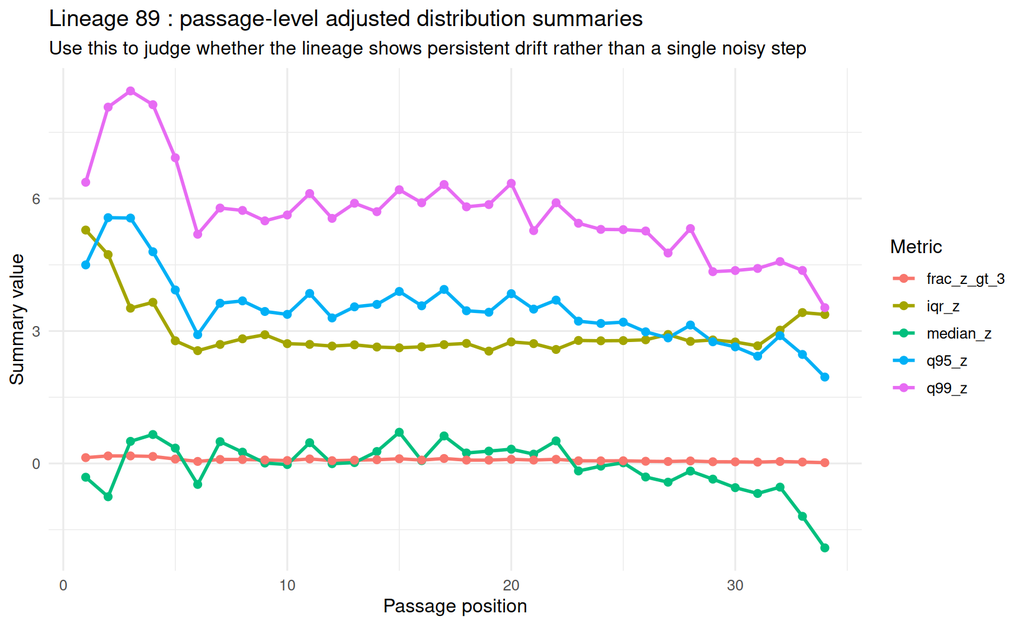

```r
focus_long_tbl <- focus_passage_tbl %>%
  select(passage_position, median_z, iqr_z, q95_z, q99_z, frac_z_gt_3) %>%
  pivot_longer(cols = -passage_position, names_to = "metric", values_to = "value")

ggplot(focus_long_tbl, aes(x = passage_position, y = value, color = metric)) +
  geom_line(linewidth = 1) +
  geom_point(size = 2) +
  geom_vline(xintercept = 1, linetype = "blank") +
  labs(
    title = paste("Lineage", focus_lineage_id, ": passage-level adjusted distribution summaries"),
    subtitle = "Use this to judge whether the lineage shows persistent drift rather than a single noisy step",
    x = "Passage position",
    y = "Summary value",
    color = "Metric"
  ) +
  theme_minimal(base_size = 12)
```

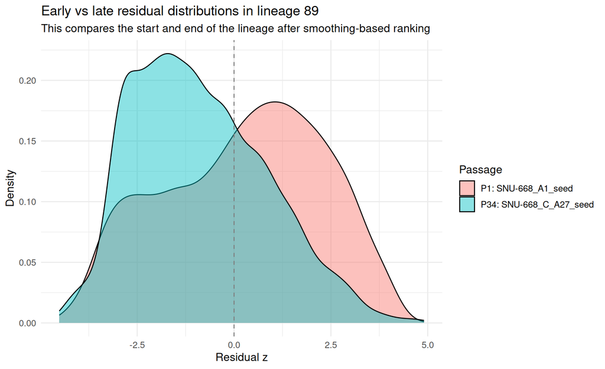

```r
target_passages <- c(focus_lineage_rank_tbl$start_passage_id[[1]], focus_lineage_rank_tbl$end_passage_id[[1]])

focus_density_tbl <- focus_cell_tbl %>%
  filter(passage_id %in% target_passages, is.finite(z), p_real >= 0.5) %>%
  group_by(passage_id) %>%
  sample_n(size = min(n(), 5000)) %>%
  ungroup() %>%
  mutate(
    passage_label = paste0("P", passage_position, ": ", passage_id)
  )

ggplot(focus_density_tbl, aes(x = z, fill = passage_label)) +
  geom_density(alpha = 0.45) +
  geom_vline(xintercept = 0, linetype = "dashed", color = "gray50") +
  labs(
    title = paste("Early vs late residual distributions in lineage", focus_lineage_id),
    subtitle = "This compares the start and end of the lineage after smoothing-based ranking",
    x = "Residual z",
    y = "Density",
    fill = "Passage"
  ) +
  theme_minimal(base_size = 12)
```

```r
transition_image_tbl <- focus_image_tbl %>%
  filter(passage_id %in% target_passages) %>%
  mutate(
    transition_side = ifelse(passage_id == target_passages[[1]], "early", "late"),
    image_rank_score = abs(median_z) + abs(q99_z) + 4 * frac_z_gt_3
  ) %>%
  arrange(desc(image_rank_score))

n_show_images <- min(nrow(transition_image_tbl), params$max_images)

knitr::kable(
  transition_image_tbl %>%
    select(
      transition_side,
      passage_position,
      passage_id,
      image_id,
      filename,
      n_objects,
      median_z,
      iqr_z,
      q99_z,
      frac_z_gt_3
    ) %>%
    slice_head(n = n_show_images),
  digits = 3
)
```

| transition_side | passage_position | passage_id | image_id | filename | n_objects | median_z | iqr_z | q99_z | frac_z_gt_3 |
| --- | --- | --- | --- | --- | --- | --- | --- | --- | --- |
| early | 1 | SNU-668_A1_seed | SNU-668_A1_seedT6 | SNU-668_A1_seedT6_10x_ph_bl.tif | 121 | 2.124 | 4.321 | 10.793 | 0.331 |
| early | 1 | SNU-668_A1_seed | SNU-668_A1_seedT6 | SNU-668_A1_seedT6_10x_ph_br.tif | 146 | 2.929 | 2.902 | 8.655 | 0.466 |
| early | 1 | SNU-668_A1_seed | SNU-668_A1_seedT6 | SNU-668_A1_seedT6_10x_ph_tl.tif | 203 | 2.186 | 3.946 | 8.200 | 0.360 |
| early | 1 | SNU-668_A1_seed | SNU-668_A1_seedT6 | SNU-668_A1_seedT6_10x_ph_tr.tif | 201 | 2.425 | 2.720 | 6.875 | 0.363 |
| early | 1 | SNU-668_A1_seed | SNU-668_A1_seedT5 | SNU-668_A1_seedT5_10x_ph_tr.tif | 244 | 1.388 | 2.122 | 7.933 | 0.156 |
| early | 1 | SNU-668_A1_seed | SNU-668_A1_seedT5 | SNU-668_A1_seedT5_10x_ph_br.tif | 227 | 1.714 | 2.691 | 5.951 | 0.242 |
| early | 1 | SNU-668_A1_seed | SNU-668_A1_seedT5 | SNU-668_A1_seedT5_10x_ph_bl.tif | 272 | 1.310 | 3.250 | 6.037 | 0.235 |
| early | 1 | SNU-668_A1_seed | SNU-668_A1_seedT2 | SNU-668_A1_seedT2_10x_ph_bl.tif | 252 | 0.516 | 3.862 | 5.928 | 0.115 |
| early | 1 | SNU-668_A1_seed | SNU-668_A1_seedT2 | SNU-668_A1_seedT2_10x_ph_tl.tif | 329 | 0.495 | 3.222 | 5.759 | 0.094 |
| late | 34 | SNU-668_C_A27_seed | SNU-668_C_A27_harvesT4 | SNU-668_C_A27_harvesT4_10x_ph_tl.tif | 1694 | -2.653 | 3.850 | 3.782 | 0.025 |

## Candidate Image Panel

```r
if (!requireNamespace("EBImage", quietly = TRUE)) {
  stop("Install EBImage to render the raw image panel.", call. = FALSE)
}

manifest_path <- project_path(params$manifest_csv)
manifest_tbl <- readr::read_csv(manifest_path, show_col_types = FALSE) %>%
  filter(artifact_type == "raw_image") %>%
  distinct(filename, filepath, .keep_all = TRUE)

direction_positive <- focus_lineage_rank_tbl$smooth_delta_q99_z[[1]] >= 0

before_tbl <- transition_image_tbl %>%
  filter(transition_side == "early")
after_tbl <- transition_image_tbl %>%
  filter(transition_side == "late")

if (direction_positive) {
  before_tbl <- before_tbl %>% arrange(median_z)
  after_tbl <- after_tbl %>% arrange(desc(median_z))
} else {
  before_tbl <- before_tbl %>% arrange(desc(median_z))
  after_tbl <- after_tbl %>% arrange(median_z)
}

half_n <- max(1, floor(params$max_images / 2))
candidate_tbl <- bind_rows(
  before_tbl %>% slice_head(n = half_n),
  after_tbl %>% slice_head(n = params$max_images - half_n)
) %>%
  left_join(manifest_tbl %>% select(filename, filepath), by = "filename") %>%
  filter(!is.na(filepath))

if (!nrow(candidate_tbl)) {
  stop("No candidate images could be matched to file paths in the manifest.", call. = FALSE)
}

knitr::kable(
  candidate_tbl %>%
    transmute(
      transition_side,
      passage_position,
      passage_id,
      filename,
      median_z = round(median_z, 3),
      q99_z = round(q99_z, 3),
      frac_z_gt_3 = round(frac_z_gt_3, 3)
    )
)
```

| transition_side | passage_position | passage_id | filename | median_z | q99_z | frac_z_gt_3 |
| --- | --- | --- | --- | --- | --- | --- |
| early | 1 | SNU-668_A1_seed | SNU-668_A1_seedT6_10x_ph_br.tif | 2.929 | 8.655 | 0.466 |
| early | 1 | SNU-668_A1_seed | SNU-668_A1_seedT6_10x_ph_tr.tif | 2.425 | 6.875 | 0.363 |
| early | 1 | SNU-668_A1_seed | SNU-668_A1_seedT6_10x_ph_tl.tif | 2.186 | 8.200 | 0.360 |
| early | 1 | SNU-668_A1_seed | SNU-668_A1_seedT6_10x_ph_bl.tif | 2.124 | 10.793 | 0.331 |
| early | 1 | SNU-668_A1_seed | SNU-668_A1_seedT5_10x_ph_br.tif | 1.714 | 5.951 | 0.242 |
| late | 34 | SNU-668_C_A27_seed | SNU-668_C_A27_harvesT4_10x_ph_br.tif | -2.784 | 3.424 | 0.014 |
| late | 34 | SNU-668_C_A27_seed | SNU-668_C_A27_harvesT4_10x_ph_tl.tif | -2.653 | 3.782 | 0.025 |
| late | 34 | SNU-668_C_A27_seed | SNU-668_C_A27_harvesT4_10x_ph_bl.tif | -1.980 | 3.326 | 0.019 |
| late | 34 | SNU-668_C_A27_seed | SNU-668_C_A27_harvesT3_10x_ph_tr.tif | -1.778 | 2.603 | 0.003 |
| late | 34 | SNU-668_C_A27_seed | SNU-668_C_A27_harvesT4_10x_ph_tr.tif | -1.774 | 4.036 | 0.027 |

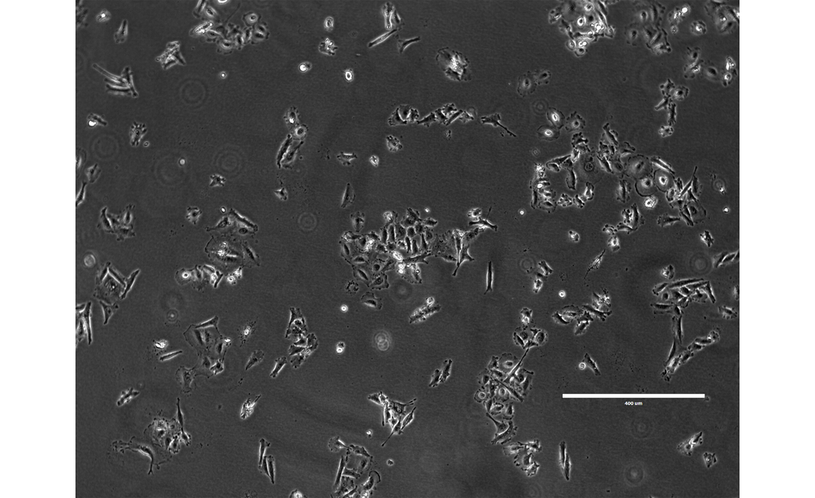

```r
img <- EBImage::readImage(candidate_tbl$filepath)
EBImage::display(img)
```

Interpretation:

- The image panel is meant as a reality check, not a formal validation step.
- If the selected before/after images show obvious segmentation artifacts, focus on nuisance fraction and image-level instability before trusting the transition.
- If the images show a coherent morphology shift that aligns with the residual summaries, that lineage becomes a strong candidate for deeper follow-up.

## Reading This Notebook

Use the output in this order:

1. Look at the transition ranking table and scatter to find candidate lineages.
2. Use the heatmap to see whether a lineage has one abrupt change or a more gradual trajectory.
3. Inspect the focus-lineage trend plots to see whether the signal is central, broad, or upper-tail-specific.
4. Check the candidate image panel to decide whether the statistical change is visually credible.

## Render

```r
rmarkdown::render(
  "workflows/lineage_area_review.Rmd",
  params = list(
    lineage_id = NULL,
    all_results_dir = "data/lineage_area",
    manifest_csv = "manifests/image_manifest.csv",
    show_images = TRUE,
    max_images = 10
  )
)
```